# DSAIT4200 Coursework B — A Transfer Learning Experiment

Reproducible analysis

Melani Evangelou, Luca Ionescu, Chris Obis, Maksym Ziemlewski

2026-06-09

# 1 Purpose and approach

The experiment measures a **metric score in `[0, 1]`** for nine models on seven test datasets (`TeD`). Transfer-learning models are trained on subsets of eight training datasets (`TrD1..TrD8`). We answer:

- **RQ1** - does transfer learning beat non-transfer baselines?
- **RQ2** - how do the **number** and **identity** of training datasets, and the **depth of refinement**, affect performance?

To achieve this, we will: (1) explore the data, (2) fit a **large preliminary model and rank effects with Type-II ANOVA** to guide the analysis, (3) **transform the response per test dataset** (within-`TeD` standardization) so effects are comparable across test sets, (4) build structure-aware models and report **effect sizes with confidence intervals** (in SD units), and (5) confirm everything with a bounded-response **logit / quasi-binomial** model.

```r
# install.packages(c("tidyverse","car","emmeans","broom","patchwork"))
library(patchwork); library(tidyverse); library(car); library(emmeans); library(broom)
theme_set(theme_bw(base_size = 11)); emm_options(rg.limit = 200000)
```

# 2 Data preparation

We derive the non-explicit factors: the **number** of training datasets `n_trd`, the architecture `model_type`, `model_group` (Baseline vs Transfer), the broad `task_type`, the **refinement depth** of the multi-`TrD` models (`MN`=0 … `MF`=4), the **within-`TeD` standardized** score `z` (primary response, SD-of-that-TeD units), and a clamped **logit** for the bounded-response robustness check.

```r
d <- readr::read_csv("data.csv", show_col_types = FALSE)
trd_cols <- paste0("TrD", 1:8); eps <- 0.005

d <- d |>
  mutate(
    n_trd       = rowSums(across(all_of(trd_cols))),
    model_group = if_else(model %in% c("B1","B2","B3"), "BL", "TR"),
    model_type  = if_else(model %in% c("B1","B2","B3"), "Baseline", model),
    task_type   = case_when(TeD %in% paste0("TeD",1:4) ~ "Classification",
                            TeD == "TeD5" ~ "Recommendation", TRUE ~ "Regression"),
    depth       = case_when(model_type=="MN"~0, model_type=="M1"~1, model_type=="M2"~2,
                            model_type=="M3"~3, model_type=="MF"~4, TRUE~NA_real_),
    logit       = qlogis(pmin(pmax(score, eps), 1 - eps))) |> # mapping (0,1) to the whole number line

  group_by(TeD) |> mutate(z = (score - mean(score)) / sd(score)) |> ungroup() |>
  mutate(TeD        = factor(TeD, levels = paste0("TeD",1:7)),
         model_group= factor(model_group, levels = c("BL","TR")),
         model_type = factor(model_type, levels = c("Baseline","MS","MN","M1","M2","M3","MF")),
         task_type  = factor(task_type, c("Classification","Recommendation","Regression")),
         across(all_of(trd_cols), as.integer))

table(d$model_type, d$n_trd)     # exposes the structural confound
```

```
##
##              0   1   2   3   4   5   6   7   8
##   Baseline  21   0   0   0   0   0   0   0   0
##   MS         0 336   0   0   0   0   0   0   0
##   MN         0   0 119 112  84  63  91  56  35
##   M1         0   0  56  63  84 133 119  56  35
##   M2         0   0 112  98  98  84  56  56  35
##   M3         0   0 126 126  77  35  70  35  35
##   MF         0   0  56  49  84 119  91  56  35
```

The cross-tabulation shows **aliasing**: baselines always use 0 training sets, `MS` always 1, `Mx` span 2–8. So “number of datasets”, “single-vs-multi” and “baseline-vs-transfer” cannot be separated globally. We isolate each effect on the appropriate subset.

# 3 Exploratory data analysis

```r
het <- d |> group_by(TeD, task_type) |>
  summarise(mean=mean(score), sd=sd(score), min=min(score), max=max(score),
            n=n(), .groups="drop"); het
```

| TeD | task_type | mean | sd | min | max | n |
| --- | --- | --- | --- | --- | --- | --- |
| TeD1 | Classification | 0.78805072 | 0.111270956 | 0.50230119 | 0.90587602 | 428 |
| TeD2 | Classification | 0.57703670 | 0.024109303 | 0.49731831 | 0.61570152 | 428 |
| TeD3 | Classification | 0.69891817 | 0.060813629 | 0.50353698 | 0.79421222 | 428 |
| TeD4 | Classification | 0.48141839 | 0.078397789 | 0.25283019 | 0.60218471 | 428 |
| TeD5 | Recommendation | 0.05004097 | 0.007500752 | 0.02420453 | 0.06143528 | 428 |
| TeD6 | Regression | 0.60545365 | 0.082402725 | 0.09866654 | 0.71739306 | 428 |
| TeD7 | Regression | 0.26725158 | 0.082761818 | 0.00000100 | 0.47530725 | 428 |

```r
cat(sprintf("within-TeD SD ranges %.3f-%.3f  (%.1fx)\n", min(het$sd), max(het$sd),
            max(het$sd)/min(het$sd)))
```

```
## within-TeD SD ranges 0.008-0.111  (14.8x)
```

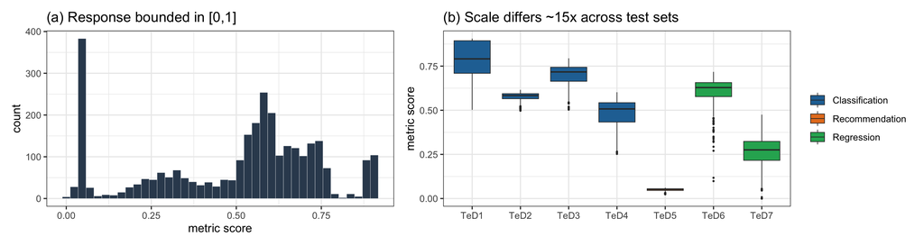

```r
p1 <- ggplot(d, aes(score)) + geom_histogram(bins=40, fill="#34495e", colour="white",
      linewidth=.1) + labs(x="metric score", y="count", title="(a) Response bounded in [0,1]")
p2 <- ggplot(d, aes(TeD, score, fill=task_type)) + geom_boxplot(outlier.size=.3, linewidth=.3) +
  scale_fill_manual(values=c(Classification="#2471a3",Recommendation="#e67e22",Regression="#27ae60")) +
  labs(x=NULL, y="metric score", fill=NULL, title="(b) Scale differs ~15x across test sets")

(p1 | p2)
```

# 4 Large preliminary model and ANOVA

We fit a large model with all available factors and key interactions and rank effects with **Type-II** sums of squares (order-independent under the unbalanced design).

```r
m_big <- lm(score ~ TeD * model_type + TeD:n_trd, data = d)
Anova(m_big, type = 2) |> tidy() |>
  mutate(pct_SS = round(100*sumsq/sum(sumsq), 1)) |> arrange(desc(pct_SS))
```

| term | sumsq | df | statistic | p.value | pct_SS |
| --- | --- | --- | --- | --- | --- |
| TeD | 169.6730163 | 6 | 8963.437348 | 0.000000e+00 | 92.6 |
| Residuals | 9.2754347 | 2940 | NA | NA | 5.1 |
| model_type | 2.3631232 | 6 | 124.838396 | 5.775350e-141 | 1.3 |
| TeD:model_type | 1.1078002 | 36 | 9.753758 | 6.804381e-50 | 0.6 |
| TeD:n_trd | 0.8018444 | 7 | 36.308233 | 5.311037e-49 | 0.4 |

`TeD` alone is ~93% of the sum of squares. Two consequences drive the rest of the analysis: (1) a high overall `R^2` is uninformative (it just reflects task differences), so we must **control for `TeD`**, and, (2) because the test sets differ in scale by ~15x, raw effects are **not comparable across `TeD`**.

# 5 Transform for homogeneity: within-`TeD` standardization

Standardizing the score within each test set removes the between-`TeD` scale and ensures **variance homogeneity** (every `TeD` has SD 1), so an effect can be read as “how many SD of *that* test set”. This is our primary response. A clamped **logit**, which respects the `[0,1]` bound, is used later as a robustness check.

```r
m_raw <- lm(score ~ TeD * model_type, data = d)   # natural scale (for intuition)
m_z   <- lm(z     ~ TeD * model_type, data = d)   # PRIMARY: SD-of-that-TeD units
summary(m_z)$adj.r.squared # expected to be lower than the raw R^2 because z already removed the giant TeD variance, leaving the interesting part to be explained
```

```
## [1] 0.3760516
```

## 5.1 Goodness of fit

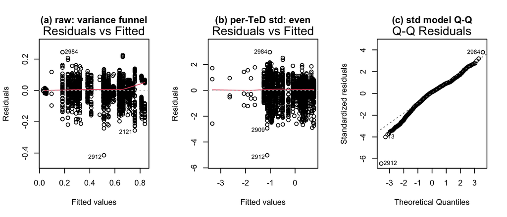

```r
par(mfrow = c(1, 3))
plot(m_raw, which = 1, main = "(a) raw: variance funnel") # funnel -> spread grows with the fitted value = heteroscedasticity
# (homoscedasticity = residual variance constant across fitted values, violated here)
plot(m_z,   which = 1, main = "(b) per-TeD std: even") # spread is now expected to be even across fitted values (assumption satisfied)
plot(m_z,   which = 2, main = "(c) std model Q-Q") # Normal Q-Q: residuals sorted vs what a Normal predicts; on the diagonal = ~Normal
```

```r
par(mfrow = c(1, 1))
```

The variance funnel of the raw model flattens after per-`TeD` standardization. The Q-Q is straight apart from a mild left tail from some genuine near-zero scores in `TeD7`. This is not a concern at `n = 2996`, where the Central Limit Theorem makes coefficient inference robust to non-Normality, and any residual non-constant variance does not change our conclusions, which we confirm with the logit and quasi-binomial models.

## 5.2 Robustness models

We refit the same model two other ways, respecting the [0,1] bound, to later check that the conclusions don’t depend on the standardization trick.

```r
m_logit <- lm(logit ~ TeD * model_type, data = d) # models the logit of the score, unsquishing the scale, with an ordinary linear model
m_qb    <- glm(pmin(pmax(score,eps),1-eps) ~ TeD * model_type,
               family = quasibinomial(), data = d) # a generalized linear model, keeps the predictions inside [0,1] and assumes proportion-like variance with a flexible dispersion
cat("quasi-binomial dispersion:", round(summary(m_qb)$dispersion,3), "\n") # the dispersion (how spread-out the data is vs. a strict binomial)
```

```
## quasi-binomial dispersion: 0.018
```

# 6 RQ1 - Does transfer learning improve over typical non-transfer learning?

## 6.1 Transfer - Baseline comparison

Effect sizes are differences in **SD units** of each test set, with 95% confidence intervals.

```r
emm <- emmeans(m_z, ~ model_type | TeD) # adjusted mean (in SD-of-TeD units) for each architecture, within each test set

contrast(emm, method = list("TR - BL" = c(-1, rep(1/6, 6))), by = "TeD") |>
  summary(infer = TRUE) # weights are aligned to model_type: Baseline, MS, MN, M1, M2, M3, MF -> -1 on Baseline, 1/6 on each of the 6 transfer-based ones -> avg transfer - baseline.
```

|  | contrast | TeD | estimate | SE | df | lower.CL | upper.CL | t.ratio | p.value |
| --- | --- | --- | --- | --- | --- | --- | --- | --- | --- |
| 1 | TR - BL | TeD1 | 1.72955550 | 0.4572488 | 2947 | 0.8329961 | 2.6261149 | 3.782526222 | 1.583298e-04 |
| 2 | TR - BL | TeD2 | 1.58634243 | 0.4572488 | 2947 | 0.6897831 | 2.4829018 | 3.469320192 | 5.292628e-04 |
| 3 | TR - BL | TeD3 | 1.87521299 | 0.4572488 | 2947 | 0.9786536 | 2.7717724 | 4.101078168 | 4.223550e-05 |
| 4 | TR - BL | TeD4 | -0.00279104 | 0.4572488 | 2947 | -0.8993504 | 0.8937683 | -0.006103985 | 9.951302e-01 |
| 5 | TR - BL | TeD5 | 2.61599617 | 0.4572488 | 2947 | 1.7194368 | 3.5125555 | 5.721165995 | 1.164173e-08 |
| 6 | TR - BL | TeD6 | 3.31061211 | 0.4572488 | 2947 | 2.4140527 | 4.2071715 | 7.240286362 | 5.686954e-13 |
| 7 | TR - BL | TeD7 | 2.03287816 | 0.4572488 | 2947 | 1.1363188 | 2.9294375 | 4.445890835 | 9.076206e-06 |

```r
contrast(emmeans(m_z, ~ model_type), method = list("TR - BL" = c(-1, rep(1/6, 6)))) |>
  summary(infer = TRUE) # same contrast, but on EMMs pooled over all test sets (single overall SD figure)
```

|  | contrast | estimate | SE | df | lower.CL | upper.CL | t.ratio | p.value |
| --- | --- | --- | --- | --- | --- | --- | --- | --- |
| 1 | TR - BL | 1.878258 | 0.1728238 | 2947 | 1.53939 | 2.217126 | 10.86805 | 5.285498e-27 |

```r
contrast(emmeans(m_z, ~ model_type), method = "trt.vs.ctrl", ref = 1) |>
  summary(infer = TRUE) # Dunnett ("Treatment vs Control") -> each architecture - baseline control, pooled over test sets
```

|  | contrast | estimate | SE | df | lower.CL | upper.CL | t.ratio | p.value |
| --- | --- | --- | --- | --- | --- | --- | --- | --- |
| 1 | MS - Baseline | 0.8831009 | 0.1774981 | 2947 | 0.4247421 | 1.341460 | 4.975270 | 4.110852e-06 |
| 2 | MN - Baseline | 1.2114998 | 0.1753975 | 2947 | 0.7585656 | 1.664434 | 6.907169 | 6.032730e-12 |
| 3 | M1 - Baseline | 2.1361249 | 0.1754787 | 2947 | 1.6829808 | 2.589269 | 12.173128 | 0.000000e+00 |
| 4 | M2 - Baseline | 2.2163947 | 0.1755209 | 2947 | 1.7631417 | 2.669648 | 12.627525 | 0.000000e+00 |
| 5 | M3 - Baseline | 2.2909981 | 0.1757493 | 2947 | 1.8371553 | 2.744841 | 13.035603 | 0.000000e+00 |
| 6 | MF - Baseline | 2.5314299 | 0.1758497 | 2947 | 2.0773278 | 2.985532 | 14.395417 | 0.000000e+00 |

```r
m_raw_grp <- lm(score ~ TeD * model_group, data = d) # separate raw score model using the BL/TR grouping to see real-scale numbers
emmeans(m_raw_grp, ~ model_group | TeD) |> summary() # baseline vs transfer mean score per test set
```

|  | model_group | TeD | emmean | SE | df | lower.CL | upper.CL |
| --- | --- | --- | --- | --- | --- | --- | --- |
| 1 | BL | TeD1 | 0.59002921 | 0.041089702 | 2982 | 0.50946217 | 0.67059624 |
| 2 | TR | TeD1 | 0.78944851 | 0.003452225 | 2982 | 0.78267953 | 0.79621750 |
| 3 | BL | TeD2 | 0.53791942 | 0.041089702 | 2982 | 0.45735238 | 0.61848646 |
| 4 | TR | TeD2 | 0.57731282 | 0.003452225 | 2982 | 0.57054383 | 0.58408180 |
| 5 | BL | TeD3 | 0.58285102 | 0.041089702 | 2982 | 0.50228398 | 0.66341805 |
| 6 | TR | TeD3 | 0.69973747 | 0.003452225 | 2982 | 0.69296848 | 0.70650645 |
| 7 | BL | TeD4 | 0.47904667 | 0.041089702 | 2982 | 0.39847964 | 0.55961371 |
| 8 | TR | TeD4 | 0.48143513 | 0.003452225 | 2982 | 0.47466615 | 0.48820412 |
| 9 | BL | TeD5 | 0.03023588 | 0.041089702 | 2982 | -0.05033116 | 0.11080292 |
| 10 | TR | TeD5 | 0.05018077 | 0.003452225 | 2982 | 0.04341178 | 0.05694975 |

[output cut: 4 more lines]

Transfer beats baseline overall (~1.88 SD) and on **six of the seven** test sets. Only `TeD4` shows no benefit. The Dunnett contrasts order the architectures `MS < MN < M1 < M2 < M3 < MF`, all above baseline, meaning that more refinement leads to larger gain.

We observe that the SE for the baseline is 0.041, whereas the transfer’s is 0.0034 (12x more precise). This is because the baseline rests on only 3 runs per test set, while the transfer has hundreds. This is also the reason for the wider confidence intervals.

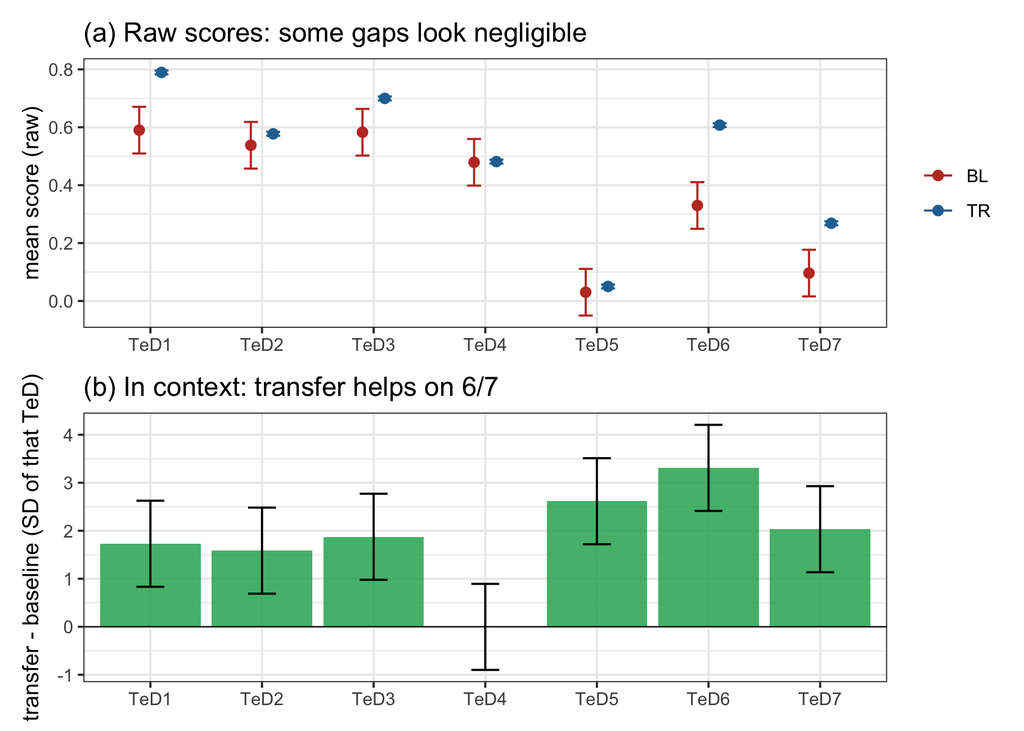

```r
# (a) raw EMMs: baseline vs transfer per test set
raw_emm <- as.data.frame(emmeans(m_raw_grp, ~ model_group | TeD))
pA <- ggplot(raw_emm, aes(TeD, emmean, colour = model_group)) +
  geom_point(position = position_dodge(.4), size = 2) +
  geom_errorbar(aes(ymin = lower.CL, ymax = upper.CL),
                position = position_dodge(.4), width = .25) +
  scale_colour_manual(values = c(BL = "#c0392b", TR = "#2471a3")) +
  labs(x = NULL, y = "mean score (raw)", colour = NULL,
       title = "(a) Raw scores: some gaps look negligible")

# (b) transfer - baseline per test set, in SD units
rq1_sd <- as.data.frame(summary(
  contrast(emm, method = list("TR - BL" = c(-1, rep(1/6, 6))), by = "TeD"),
  infer = TRUE)) |>
  mutate(signif = lower.CL > 0 | upper.CL < 0)
pB <- ggplot(rq1_sd, aes(TeD, estimate, fill = signif)) +
  geom_col(alpha = .85) +
  geom_errorbar(aes(ymin = lower.CL, ymax = upper.CL), width = .25) +
  geom_hline(yintercept = 0, linewidth = .3) +
  scale_fill_manual(values = c(`TRUE` = "#27ae60", `FALSE` = "#7f8c8d"), guide = "none") +
  labs(x = NULL, y = "transfer - baseline (SD of that TeD)",
       title = "(b) In context: transfer helps on 6/7")

(pA / pB)
```

## 6.2 Transfer-model refinement depth analysis

```r
md <- d |> filter(model_type %in% c("MN","M1","M2","M3","MF"))
emtrends(lm(z ~ TeD + depth, data = md), ~ 1, var = "depth") |> summary(infer = TRUE)
```

|  | 1 | depth.trend | SE | df | lower.CL | upper.CL | t.ratio | p.value |
| --- | --- | --- | --- | --- | --- | --- | --- | --- |
| 1 | overall | 0.2839266 | 0.01066627 | 2631 | 0.2630115 | 0.3048417 | 26.6191 | 1.908968e-138 |

Filtering to the multi-source models, where `depth` runs 0-4, and fitting a linear model that controls for `TeD`, we read off the one common slope = SD gained per refined part (0.28, CI [0.26, 0.31]).

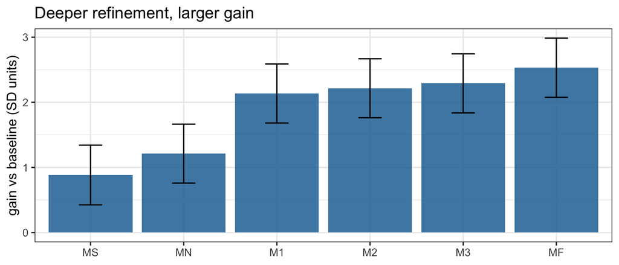

```r
# (b) each architecture vs baseline (Dunnett), SD units
dunn <- as.data.frame(summary(
  contrast(emmeans(m_z, ~ model_type), method = "trt.vs.ctrl", ref = 1), infer = TRUE)) |>
  mutate(arch = factor(sub(" - Baseline", "", contrast),
                       levels = c("MS","MN","M1","M2","M3","MF")))
pD <- ggplot(dunn, aes(arch, estimate)) +
  geom_col(fill = "#2471a3", alpha = .85) +
  geom_errorbar(aes(ymin = lower.CL, ymax = upper.CL), width = .25) +
  labs(x = NULL, y = "gain vs baseline (SD units)",
       title = "Deeper refinement, larger gain")

pD
```

# 7 RQ2 - How is the model performance affected by the choice of training datasets?

## 7.1 Number of training datasets (multi-`TrD` subset)

We only consider the 5 multi-source models where `n_trd` ranges from 2-8 freely, breaking the baseline=0 and MS=1 confound. `n_c` represents “datasets above/below average”, making the intercept and slope interpretable. We also fit a richer model with a square term I(n_c^2), allowing the line to bend, then anova (small, big) tests “does the curve fit significantly better than the straight line?” or technically “does adding I(n_c^2) drop the residual error by more than chance?”. Significance, in this case, means that the straight line is too simple and a curvature is real. To know that it is diminishing, we check the sign of the I(n_c^2) coefficient: negative = the curve bends downward = the slope shrinks as n_c grows = each extra dataset helps less = diminishing returns.

```r
mx <- d |> filter(model_type %in% c("M1","M2","M3","MF","MN")) |>
  mutate(n_c = n_trd - mean(n_trd))

m_num <- lm(z ~ TeD + n_c, data = mx) # linear model, using + (one common slope, no interaction), TeD is here to control the task, n_c carries the effect of interest

emtrends(m_num, ~ 1, var = "n_c") |> summary(infer = TRUE) # "how much z changes per dataset" -> overall slope (different heights for each test set) because there is no TeD:n_c interaction
```

|  | 1 | n_c.trend | SE | df | lower.CL | upper.CL | t.ratio | p.value |
| --- | --- | --- | --- | --- | --- | --- | --- | --- |
| 1 | overall | 0.1376503 | 0.008832097 | 2631 | 0.1203318 | 0.1549689 | 15.58524 | 1.888768e-52 |

```r
anova(m_num, lm(z ~ TeD + n_c + I(n_c^2), data = mx))
```

|  | Res.Df | RSS | Df | Sum of Sq | F | Pr(>F) |
| --- | --- | --- | --- | --- | --- | --- |
| 1 | 2631 | 1821.737 | NA | NA | NA | NA |
| 2 | 2630 | 1804.401 | 1 | 17.3368 | 25.26922 | 5.320987e-07 |

```r
m_quad <- lm(z ~ TeD + n_c + I(n_c^2), data = mx)
summary(m_quad)        # looking at the I(n_c^2) row, "Estimate" column
```

```
##
## Call:
## lm(formula = z ~ TeD + n_c + I(n_c^2), data = mx)
##
## Residuals:
##     Min      1Q  Median      3Q     Max
## -3.3585 -0.4554  0.1853  0.5714  2.2806
##
## Coefficients:
##              Estimate Std. Error t value Pr(>|t|)
## (Intercept)  0.242213   0.045842   5.284 1.37e-07 ***
## TeDTeD2     -0.008125   0.060330  -0.135    0.893
## TeDTeD3     -0.012531   0.060330  -0.208    0.835
## TeDTeD4     -0.044465   0.060330  -0.737    0.461
## TeDTeD5     -0.015389   0.060330  -0.255    0.799
## TeDTeD6      0.011882   0.060330   0.197    0.844
## TeDTeD7     -0.011902   0.060330  -0.197    0.844
## n_c          0.147686   0.009015  16.381  < 2e-16 ***
## I(n_c^2)    -0.025082   0.004990  -5.027 5.32e-07 ***
## ---
## Signif. codes:  0 '***' 0.001 '**' 0.01 '*' 0.05 '.' 0.1 ' ' 1
##
## Residual standard error: 0.8283 on 2630 degrees of freedom
## Multiple R-squared:  0.09354,    Adjusted R-squared:  0.09078
## F-statistic: 33.92 on 8 and 2630 DF,  p-value: < 2.2e-16
```

We notice that adding the term drops the residual error (RSS) from 1821.7 to 1804.4, a reduction of 17.3 for 1 extra parameter, giving F=25.3 at p = 5.3e-07. So, the curve term is significant, although a minor part of the variance (17 out of 1822), which is what “diminishing returns” are, a subtle bend. The I(n_c^2) coefficient is -0.025, therefore the curve is concave and the returns are diminishing. The linear term is 0.14 (SD per dataset on average).

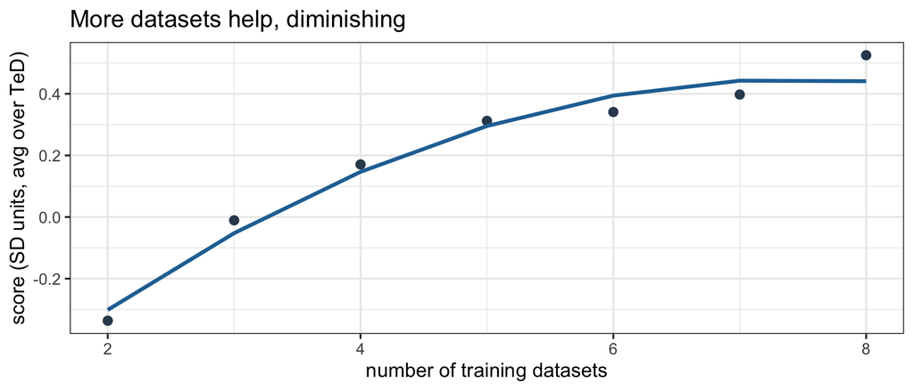

```r
# (a) number-of-datasets trend (SD units, averaged over TeD)
obs <- mx |> group_by(TeD, n_trd) |> summarise(z = mean(z), .groups = "drop") |>
  group_by(n_trd) |> summarise(z = mean(z), .groups = "drop")
newd <- expand.grid(TeD = levels(mx$TeD), n_trd = sort(unique(mx$n_trd)))
newd$n_c  <- newd$n_trd - mean(mx$n_trd)
newd$pred <- predict(m_quad, newdata = newd)
fit <- newd |> group_by(n_trd) |> summarise(pred = mean(pred), .groups = "drop")
pC <- ggplot() +
  geom_point(data = obs, aes(n_trd, z), size = 2, colour = "#34495e") +
  geom_line(data = fit, aes(n_trd, pred), colour = "#2471a3", linewidth = 1) +
  labs(x = "number of training datasets", y = "score (SD units, avg over TeD)",
       title = "More datasets help, diminishing")

pC
```

## 7.2 Which training datasets help or hurt and when

We filter out the non-transfer runs to keep the subset where the eight `TrD` vary. Next, we fit a linear model to a formula that gives each dataset a main effect and a `TeD` interaction and observe the effects (slopes). ANOVA also tells us if a more complex model that allows datasets to have a distinct effect depending on the target provides a better fit for the data or not, therefore a dataset’s usefulness depends on the test set.

```r
tr   <- d |> filter(n_trd >= 1)
m_id <- lm(as.formula(paste("z ~ TeD * (", paste(trd_cols, collapse=" + "), ")")), data = tr) # z ~ TeD * (TrD1 + ... + TrD8)
incl <- map_dfr(trd_cols, function(k){ # loop the function over each dataset name k
  et <- summary(emtrends(m_id, ~ 1, var = k), infer = TRUE) # the slope of z w.r.t. TrD k, i.e. the effect of including/excluding the dataset, since TrD is coded 1/0
  tibble(TrD=k, delta_SD=et[[paste0(k,".trend")]], lower=et[["lower.CL"]],
         upper=et[["upper.CL"]], p=et[["p.value"]]) # one row result
}) |> arrange(desc(delta_SD)); incl # most helpful first
```

| TrD | delta_SD | lower | upper | p |
| --- | --- | --- | --- | --- |
| TrD8 | 0.52635069 | 0.46900867 | 0.5836927 | 9.346359e-69 |
| TrD5 | 0.40960713 | 0.34955378 | 0.4696605 | 1.238607e-39 |
| TrD7 | 0.34908305 | 0.29062462 | 0.4075415 | 5.624374e-31 |
| TrD2 | 0.22678518 | 0.17228370 | 0.2812867 | 4.970795e-16 |
| TrD3 | 0.18125841 | 0.12297815 | 0.2395387 | 1.213919e-09 |
| TrD6 | 0.12096084 | 0.06507170 | 0.1768500 | 2.267174e-05 |
| TrD4 | 0.09816895 | 0.03848824 | 0.1578497 | 1.272374e-03 |
| TrD1 | -0.38558964 | -0.44318973 | -0.3279895 | 2.794468e-38 |

```r
anova(lm(as.formula(paste("z ~ TeD +", paste(trd_cols, collapse="+"))), data=tr), m_id) # ANOVA to compare the 2 and see whether a dataset's usefulness depends on the target task -> it does
```

|  | Res.Df | RSS | Df | Sum of Sq | F | Pr(>F) |
| --- | --- | --- | --- | --- | --- | --- |
| 1 | 2960 | 2028.703 | NA | NA | NA | NA |
| 2 | 2912 | 1615.972 | 48 | 412.7312 | 15.49471 | 5.170882e-110 |

```r
# per-test-set inclusion effect
for (k in trd_cols) print(summary(emtrends(m_id, ~ TeD, var = k), infer = TRUE))
```

```
##  TeD  TrD1.trend     SE   df lower.CL upper.CL t.ratio p.value
##  TeD1     -0.260 0.0777 2912   -0.413   -0.108  -3.348  0.0008
##  TeD2     -0.497 0.0777 2912   -0.649   -0.344  -6.392 <0.0001
##  TeD3     -0.628 0.0777 2912   -0.780   -0.475  -8.076 <0.0001
##  TeD4     -0.331 0.0777 2912   -0.483   -0.179  -4.258 <0.0001
##  TeD5     -0.524 0.0777 2912   -0.676   -0.371  -6.738 <0.0001
##  TeD6     -0.178 0.0777 2912   -0.331   -0.026  -2.295  0.0218
##  TeD7     -0.281 0.0777 2912   -0.434   -0.129  -3.620  0.0003
##
## Results are averaged over the levels of: TrD1, TrD2, TrD3, TrD4, TrD5, TrD6, TrD7, TrD8
## Confidence level used: 0.95
##  TeD  TrD2.trend     SE   df lower.CL upper.CL t.ratio p.value
##  TeD1     1.6979 0.0735 2912  1.55373  1.84212  23.088 <0.0001
##  TeD2     0.1540 0.0735 2912  0.00976  0.29816   2.094  0.0364
##  TeD3     0.0258 0.0735 2912 -0.11836  0.17003   0.351  0.7254
##  TeD4    -0.3077 0.0735 2912 -0.45193 -0.16354  -4.185 <0.0001
##  TeD5    -0.4083 0.0735 2912 -0.55246 -0.26406  -5.551 <0.0001
##  TeD6    -0.1521 0.0735 2912 -0.29627 -0.00788  -2.068  0.0387
##  TeD7     0.5778 0.0735 2912  0.43365  0.72205   7.858 <0.0001
##
## Results are averaged over the levels of: TrD1, TrD2, TrD3, TrD4, TrD5, TrD6, TrD7, TrD8
## Confidence level used: 0.95
##  TeD  TrD3.trend     SE   df lower.CL upper.CL t.ratio p.value
##  TeD1     0.1176 0.0786 2912  -0.0366    0.272   1.496  0.1348
##  TeD2     0.3148 0.0786 2912   0.1606    0.469   4.003 <0.0001
##  TeD3     0.0248 0.0786 2912  -0.1293    0.179   0.316  0.7520
##  TeD4     0.2383 0.0786 2912   0.0841    0.393   3.030  0.0025
##  TeD5     0.2565 0.0786 2912   0.1023    0.411   3.262  0.0011
##  TeD6     0.2266 0.0786 2912   0.0725    0.381   2.882  0.0040
##  TeD7     0.0900 0.0786 2912  -0.0642    0.244   1.145  0.2524
##
## Results are averaged over the levels of: TrD1, TrD2, TrD3, TrD4, TrD5, TrD6, TrD7, TrD8
## Confidence level used: 0.95
##  TeD  TrD4.trend     SE   df  lower.CL upper.CL t.ratio p.value
##  TeD1     0.0549 0.0805 2912 -0.103014   0.2128   0.682  0.4956
##  TeD2     0.1574 0.0805 2912 -0.000541   0.3153   1.954  0.0508
##  TeD3     0.0281 0.0805 2912 -0.129751   0.1860   0.350  0.7267
##  TeD4     0.2392 0.0805 2912  0.081301   0.3971   2.970  0.0030
##  TeD5     0.2140 0.0805 2912  0.056121   0.3719   2.658  0.0079
##  TeD6     0.1712 0.0805 2912  0.013315   0.3291   2.126  0.0336
```

[output cut: 33 more lines]

```
##  TeD7      0.379 0.0789 2912   0.2247    0.534   4.810 <0.0001
##
## Results are averaged over the levels of: TrD1, TrD2, TrD3, TrD4, TrD5, TrD6, TrD7, TrD8
## Confidence level used: 0.95
##  TeD  TrD8.trend     SE   df lower.CL upper.CL t.ratio p.value
##  TeD1      0.206 0.0774 2912   0.0539    0.357   2.657  0.0079
##  TeD2      0.625 0.0774 2912   0.4734    0.777   8.080 <0.0001
##  TeD3      0.692 0.0774 2912   0.5403    0.844   8.944 <0.0001
##  TeD4      0.588 0.0774 2912   0.4363    0.740   7.600 <0.0001
##  TeD5      0.674 0.0774 2912   0.5222    0.826   8.710 <0.0001
##  TeD6      0.458 0.0774 2912   0.3059    0.609   5.915 <0.0001
##  TeD7      0.442 0.0774 2912   0.2904    0.594   5.713 <0.0001
##
## Results are averaged over the levels of: TrD1, TrD2, TrD3, TrD4, TrD5, TrD6, TrD7, TrD8
## Confidence level used: 0.95
```

We observe that including `TrD8/TrD5/TrD7` helps most. `TrD2/TrD3/TrD6/TrD4` help mildly. **`TrD1` hurts**. The `TrD - TeD` interaction is highly significant, cutting the RSS from 2028.7 to 1616.0 (a difference of 412.7 points or 20% of Model 1’s RSS) for those 48 terms, with a significant F = 15.5 at p < 2.2e-16: dataset usefulness depends on the target task.

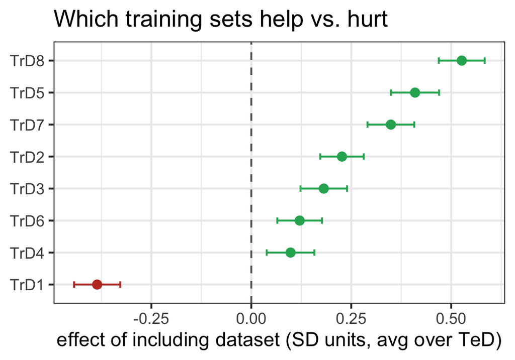

```r
ggplot(incl, aes(delta_SD, reorder(TrD, delta_SD), colour = delta_SD > 0)) +
  geom_vline(xintercept = 0, linetype = "dashed", colour = "grey40") +
  geom_errorbarh(aes(xmin = lower, xmax = upper), height = .2) +
  geom_point(size = 2) +
  scale_colour_manual(values = c(`TRUE` = "#27ae60", `FALSE` = "#c0392b"), guide = "none") +
  labs(x = "effect of including dataset (SD units, avg over TeD)", y = NULL,
       title = "Which training sets help vs. hurt")
```

# 8 Robustness: do conclusions hold on the bounded (logit) scale?

We define a reusable function that computest the per-test-set transfer - baseline contrast, with the same weights as in RQ1. Then, we match the m_z, m_logit and m_qb tables on TeD, renaming columns appropriately, and then flag whether all three agree in the direction per test set, i.e. the robustness verdict.

```r
chk <- function(model) contrast(emmeans(model, ~ model_type | TeD),
        method = list(d = c(-1, rep(1/6,6))), by="TeD") |> summary() |>
        transmute(TeD, est = estimate)
chk(m_z)    |> rename(SD_units = est) |>
  left_join(chk(m_logit) |> rename(logit    = est), by = "TeD") |>
  left_join(chk(m_qb)    |> rename(quasibin = est), by = "TeD") |>
  mutate(sign_agrees = sign(SD_units) == sign(logit) &
           sign(SD_units) == sign(quasibin))
```

| TeD | SD_units | logit | quasibin | sign_agrees |
| --- | --- | --- | --- | --- |
| TeD1 | 1.72955550 | 1.03785327 | 0.944450190 | TRUE |
| TeD2 | 1.58634243 | 0.15508886 | 0.155424928 | TRUE |
| TeD3 | 1.87521299 | 0.50556052 | 0.503395178 | TRUE |
| TeD4 | -0.00279104 | 0.00378542 | -0.002869284 | FALSE |
| TeD5 | 2.61599617 | 0.51902012 | 0.516231414 | TRUE |
| TeD6 | 3.31061211 | 1.26610019 | 1.129553367 | TRUE |
| TeD7 | 2.03287816 | 1.93346291 | 1.181540068 | TRUE |

The results show that the modelling did not distort the results. 6 of 7 test sets are `TRUE`, showing that on each one there is a real effect, agreed by 3 different ways of computation. `TeD4` = `FALSE` is a non-issue because, looking at its -0.003, +0.004, -0.003 values, they are essentially zero, flipping harmlessly between methods, and we can easily mark this as noise. This disagreement actually reinforces our RQ1, with `TeD4` having no real effect.